# Single and multiple imputation methods

# Single imputation

Single imputation involves less computation, and provides the dataset with a specific number in place of the missing data.

In addition, single imputation is a first step to multiple imputation.

## Matching methods - Hot Deck imputation

This method is based on analyse complete instances and look for the most similar (or a set of the most similar) responses the individual would have answered, and then picks one of those possible responses at random and places it in the dataset.

## Methods assuming dependence between columns

The most popular strategy is imputing with the mean of the observed values. But you may take into account the relationship between variables and impute missing entry with predictions of model based on other variables.

### Regression imputation

For numeric variables linear regression is often presumed, for instance we assume that variable $Ozone$ is dependent to $Solar.R$ feature. Generally

$$X_1 \sim X_2 + ... + X_p$$

Inner model is estimated and missing values are replaced with predictions. The imputed values correspond to the most likely values under the model. This models are fitted only **once** and on the whole dataset.

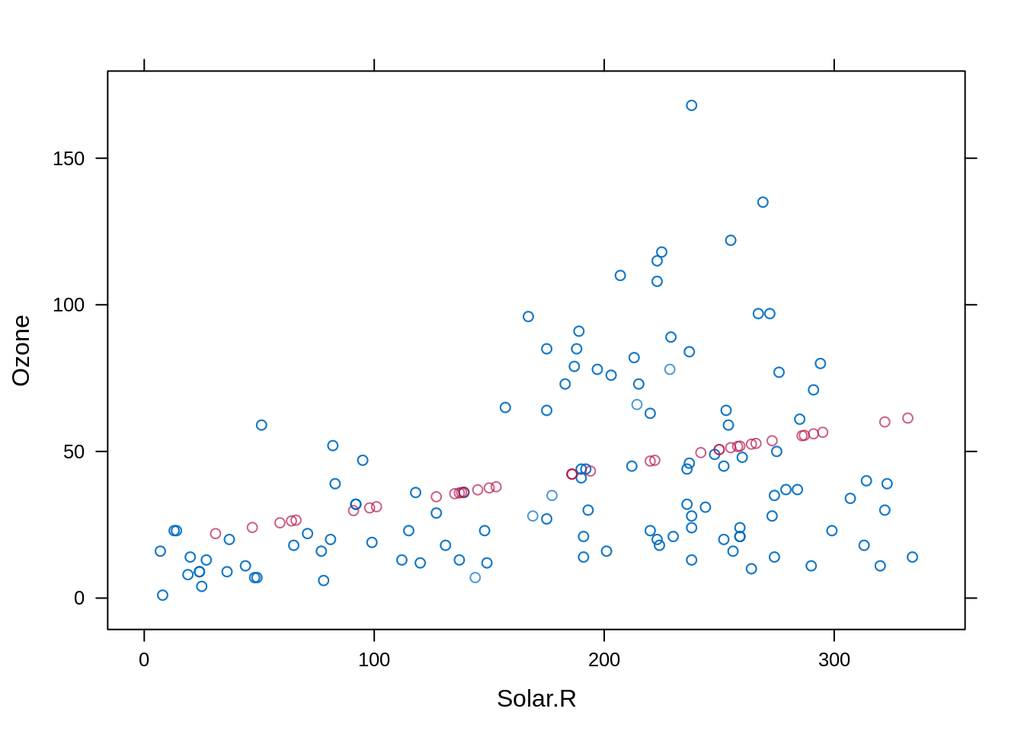

INFO: for categorical variables with missings instead linear regression, logistic regression can be assumed.

Cons:

- **regression imputation artificially strengthens the relations in the data**, correlation in completed data are bias
- variance of completed data is underestimated
- in single regression we can use only columns without missing values as predictive variables.

### Stochastic regression

Stochastic regression imputation is a refinement of regression imputation attempts to address correlation bias by adding noise to the predictions. The noise component is a random draw from a Gaussian distribution with mean zero and variance equals to the residuals variance.

$$X_1 \sim X_2 + ... + X_p + noise$$

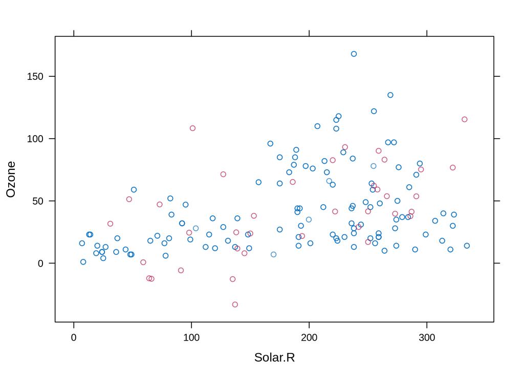

Pros in comparion to regression methods: - reduced correlation bias and variance underestimated

Cons:

- **no uncertainity assessment**, for instance model fitted on subsample of data gives different model coefficients and predictions
- we can only use complte columns as predictive features
- we have to assume adequate of model

### Sequential regression models by conditional imputation

In data we may have more than one column with missing data. In above mentioned regression methods only fully complted columns are allowed as explanatory features. Sequential conditional imputation enables use information from features with missings.

Algorithm is iterrative.

1. The initial step is replacement all missing values with guessing values (for instance mean).
2. We start imputation from columns with least missing entries and replaced them with prediction of model based on all remaining features. In next step succeeding features with missing values are updated.
3. Operations are repeated up to fullfilling stopping criteria.

This relation may be modelled in parametric models (eg. linear model or logistic classifications) or in nonparametric (eg. **random forest**)

Pros: - We can use all observed data as predictive features not only with all complete instances

Cons: - ignores any sampling uncertainty - we have to assume adequate of model

## Low rank matrix approximation

Fitting a low-rank matrix approximation to a matrix with missing values using eg. SVD decomposition ($Z = UDV$). The matrix approximation $\hat{X}_{n \times p}$ is sought by minimizing objective criteria - gives the best approximation of the matrix X in the least squares sense

$$|| X_{n \times p} - \hat{X}_{n \times p}||^2$$
This approximation with filled missing data is found via different methods but obtained matrix $\hat{X}$ is always low rank. Some methods assume the rank of approximation matrix, some techniques involve special regularization and this assure low rank.

Most methods find matrix approximation in iterative algorithms.

Missing values are replaces with corresponding values from matrix approximation.

# Multiple imputation

Common darwback of so far descibed methods is that we impute only single value for missing data and we can control how uncertain it can be. Our level of confidence in a particular imputed value may expressed as the variation across the $m$ completed datasets.

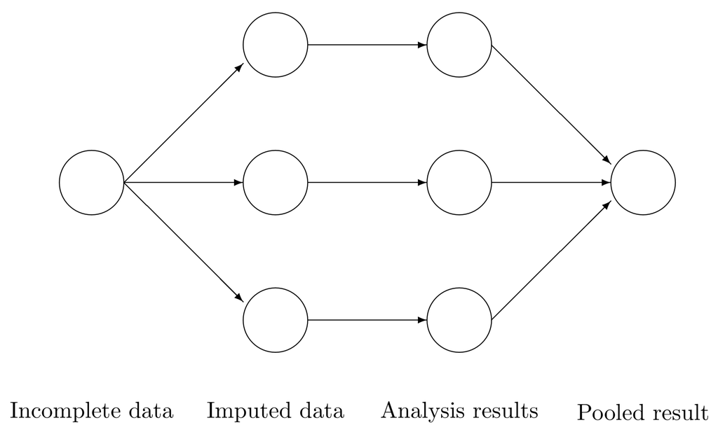

Multiple imputation workflow

1. Create $m$ sets of imputations for the missing values using an imputation process with a random component.
2. The result is $m$ full data sets. Each data set will have slightly different values for the imputed data because of the random component.
3. Analyze each completed data set. Each set of parameter estimates will differ slightly because the data differs slightly.
4. Pool results (average the values of the parameter estimates across the missing value samples in order to obtain a single point estimate), calculating the variation (standard error) in parameter estimates.

### Matching methods

Extension of single matching methods.

For each missing entry, the method forms a small set of candidate instances from complete dataset with predicted values closest to the predicted value for the missing entry. On the base of these similar observations missing value is replaces with mean, randomly drawn value or other simple imputated value.

### Multiple sequential regression models by conditional imputation

This is the extension on single sequential imputation. Monitioring of uncertainity may be accomplish with various approach, for example:

- fitting sequentiql regression models on randomly picked subsamples of data (bootstrapping).
- adding random component during fitting regression coefficents in imputation model (Bayesian methods) .

Multiple imputed dataset are generated with different random seed in bootstarp or are generated in repeated Bayesian regression.

### Methods assuming multivariate distribution.

On base of randomly selected of subsamples of data (bootstrap) this multivariate distribution is fitted to data.

In this type estimation often applied is EM algorithm - Expectation Maximatization. We have to assume specific distribution (likelihood function) and this assumption involves estimation of distribution parameters ($\mu, \Sigma$). Iterative algorithm choose parametres of this distribution as the most *likely* on base of data (maximize expectation function).

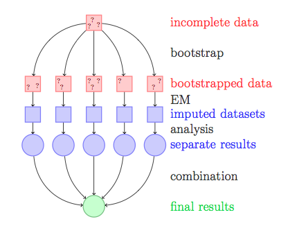

### Squential methods based on decomposition of data matrix

This is the extension on low matrix imputation